# Egzaminas

Rūta Radavičiūtė

Wednesday, June 15, 2016

```r
library(car)
library(fpp)
library(dynlm)
library(knitr)
```

## Užduotis 2 (numatyta 30 taškų)

Faile ‘data_b.csv’ yra pateikti duomenys reikalingi tiesinės regresijos tyrimui. Duomenų masyvo aprašymas pateiktas minėto failo gale.

1. Duomenų apžvalga ir paruošimas. Šioje dalyje jums reikia susipažinti su duomenimis ir paruošti duomenis tolimesnei analizei.
1. Nuskaitykite duomenų masyvą. Jeigu įmanoma, nekoreguokite originalaus failo.

```r
#dat<-read.csv2("data_b.csv", header=T) #neiseina tinkamai nusiskaityti duomenu, taciau pabandysiu kitus zingsnius parasyti kaip galima atlikti teoriskai
```

2. Paruoškite duomenis naudojimui. Jūs turite užtikrinti, kad:
   - Neliko įrašų su trūkstamomis reikšmėmis - jeigu šalinote įrašus, tai būtinai raportuokite kiek įrašų pašalinta ir kiek liko.

```r
#sum(dat == "MISSING") bus pranesta, kurios reiksmes yra trukstamos
```

```
* Duomenų masyve nėra kažkokių klaidų (pvz. negalimos reikšmės, neteisingas duomenų tipas,
didelės išskirtys ir t.t.)
```

```r
#Isskirtis galima tikrinti su boxplot
#Arba
#Isskirtis tinkriname su influence.measures, pasitarius tiesini modeli ir parametras cook.d (*) parodo išskirtis
#Arba
#isskirtis tikriname su outlierTest taip pat pasidarius tiesini modeli
```

3. Pateikite trumpą kintamųjų apžvalgą. Naudokite tik tuos duomenis (ir kintamuosius), kuriuos planuojate taikyti tyrimui, t.y. jei reikėjo ką nors modifikuoti, tai senųjų reikšmių naudoti nebereikia. Šiai apžvalgai užtenka informacijos, kurią pateikia funkcijos `plot`, `summary` ir `cor`.

```r
#Is plot galime pasakyti ar duomenys koreliuoja ar yra matomos ryskios isskirtis
#Summry suteiks informacija apie vidurkius, medianas
#Cor galima paziureti dvieju kintamuju tarpusavio koreliacija ar visu kintamuju koreliacija
```

4. Duomenų masyvą suskaidykite į du atskirus ir nesikertančius masyvus. Didesnį masyvą turi sudaryti apie 80 proc. turimų stebėjimų. Šį masyvą vadinsime `trainSet`. Mažesnį masyvą turi sudaryti likę įrašai. Šį masyvą vadinsime `testSet`. Duomenų suskaidymas turi būti atsitiktinis. Gali būti naudingos šios funkcijos:`sample`, `setdiff`, `%in%`.

```r
# http://stackoverflow.com/questions/17200114/how-to-split-data-into-training-testing-sets-using-s## ample-function-in-r-program
#Cia galima matyti kaip reikia padalinti duomenis
```

2. Tiesinio modelio sudarymas. Modelio sudarymui naudokite `trainSet` masyvą.
1. Įvertinkite tiesinį modelių, kuriame prognozuojamas kintamasis būtų išlaios vaisiams. Jos turi tiesiškai priklausyti nuo kitų kintamųjų.
2. Ar visi įtraukti kintamieji daro reikšmingą įtaką prognozei? Jei ne, koreguokite modelį, kad visi kintamieji darytų reikšmingą įtaką.

```r
#Is modelio summary lenteles pagal p-value kuris didesnis uz 0.05 galime matyti, kurie kintamieji yra nereiksmingi
```

3. Patikrinkite modelio savybes (multikolinerumą, heteroskedastiškumą ir paklaidų normalumą). Jei kuri nors savybė nėra gera, tai pakomentuokite kokios to gali būti pasekmės (ar rizikos).
3. Modelio tobulinimas. Ar gali būti, kad duomenyse pasireiškė netiesinė sąveika? Siekiant ją patikti prasminga pasižiūrėti sklaidos diagramą tarp modelio paklaidų ir tiriamų kintamųjų.
1. Pateikite dvi sklaidos diagramas. Pirmoji tarp modelio paklaidų ir `butinosIslaidos` kintamojo. O antroji, tarp modelio paklaidų ir `pajamos` kintamojo. Pakomentuokite rezultatus. Tendencijų išryškinimui gali būti naudinga `lowess` funkcija.
2. Tikėtina, kad ne visų duomenų priklausomybė yra tiesinė. Kokius pakeitimus siūlytumėte? Pabandykite sumažinti netiesiškumo pasekmes. Galutinį modelio variantą žymėsime `fit2`.
4. Modelių palyginimas ir prognozė.
1. Suskaičiuokite modelių `fit1` ir `fit2` RMSE, $MSE = \frac{1}{n} \sum_{i=1}^n \varepsilon_t^2.$

MSE suskaičiuokite abiem duomenų masyvams `trainSet` ir `testSet`. Rezultatus sudėkite į lentelę. Palyginkite rezultatus ir padarykite išvadas. Kuris modelis geresnis? Geresnį modelį žymėsime `fitMain`. Užrašykite šio modelio lygtį.

2. Išbrėžkite sklaidos diagramą, kurioje $x$ ašyje būtų `fitMain` modelio `testSet` prognozė, o $y$ ašyje faktinės `testSet` pajamų reikšmės.
3. Kiek procentų `testSet` reikšmių buvo aukščiau nei atitinkamų pasikliautinių intervalų (80 proc.) didesnioji reikšmė?

## Užduotis 3

Pakete `dynlm` yra duomenų masyvas `M1Germany`.

1. Duomenų paruošimas ir pažvalga.

```r
library(dynlm)
summary(M1Germany)
```

```
##      Index          logm1          logprice         loggnp
##  Min.   :1960   Min.   :7.947   Min.   :3.380   Min.   :8.309
##  1st Qu.:1969   1st Qu.:8.229   1st Qu.:3.687   1st Qu.:8.687
##  Median :1978   Median :8.527   Median :4.193   Median :8.957
##  Mean   :1978   Mean   :8.492   Mean   :4.128   Mean   :8.880
##  3rd Qu.:1987   3rd Qu.:8.746   3rd Qu.:4.487   3rd Qu.:9.090
##  Max.   :1996   Max.   :9.049   Max.   :4.764   Max.   :9.206
##                 NA's   :3       NA's   :1       NA's   :3
##     interest
##  Min.   :0.05500
##  1st Qu.:0.06200
##  Median :0.07200
##  Mean   :0.07434
##  3rd Qu.:0.08300
##  Max.   :0.11300
##
```

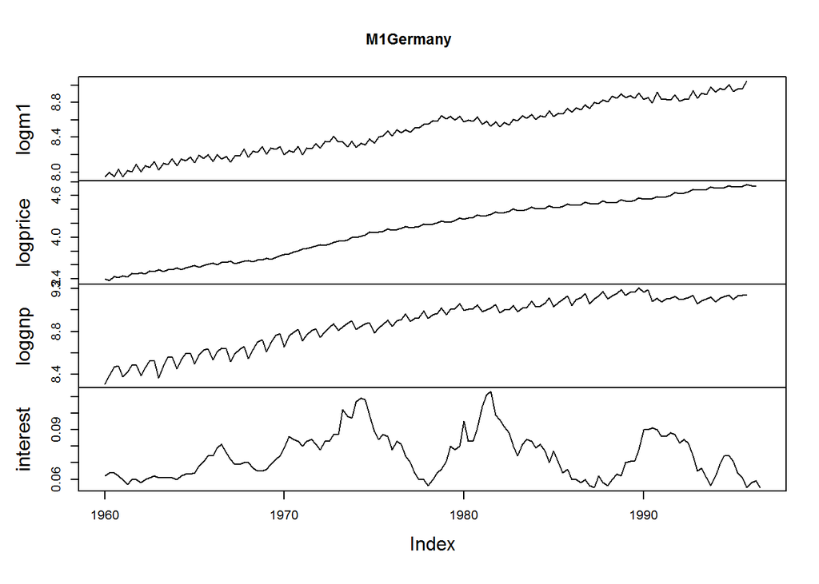

```r
plot(M1Germany)
```

1. Minėtame duomenų masyve yra `logprice` kintamasis, kuris žymi kainų indekso logiritmą. Iš šio kintamojo jums reikia įvertinti kainų vidutinį santykini augimo tempą. Vidutinis santykini augimo tempas pasižymi savybe: jei nuo pirmojo stebėjimo $x_1$, kiti duomenys didėtų pastoviu santykinių greičiu, tai po $N$ laikoterpių apskaičiuota reikšmė bus lygi paskutiniam stebėjimui $x_N$, t.y. galioja lygybė: $x_1 (1 + \mu)^N =x_N$,

kur $\mu$ yra vidutinis santykinis augimo tempas.

1. Įvertinkite tiesinę regresija žemiau pateikto modelio:

$logprice_t = \beta_0 + \beta_1 loggnp_{t-1} + \beta_2 \Delta loggnp_{t-2} + s_t + \varepsilon_t,$ čia $s_t$ žymi sezoninę komponentę.

```r
mod1 <- dynlm(logprice ~ L(loggnp,1)+(d(L(loggnp,2))), data = M1Germany)
mod1
```

```
##
## Time series regression with "zooreg" data:
## Start = 1960 Q4, End = 1996 Q1
##
## Call:
## dynlm(formula = logprice ~ L(loggnp, 1) + (d(L(loggnp, 2))),
##     data = M1Germany)
##
## Coefficients:
##     (Intercept)     L(loggnp, 1)  d(L(loggnp, 2))
##        -11.0615           1.7105          -0.2649
```

```r
#nezinau kaip prideti sezonine komponente todel sukuriau tiesine regresija be jos
```

2. Gaukite įvertintos lygties liekanas. Jas vadinsime `ser`. Rekomenduojama liekanų objektą transformuoti į laiko eilučių klasę (`ts`).

```r
ser<-mod1$res
ser<-as.ts(ser)
```

3. Ar `ser` laiko eilutė stacionari. Jei ne - raskite skirtumų operacijas, kurios pasiektų stacionarumą. Jeigu naudojate automatines procedūras, tai atsakymą patikrinkite ekspertiškai.

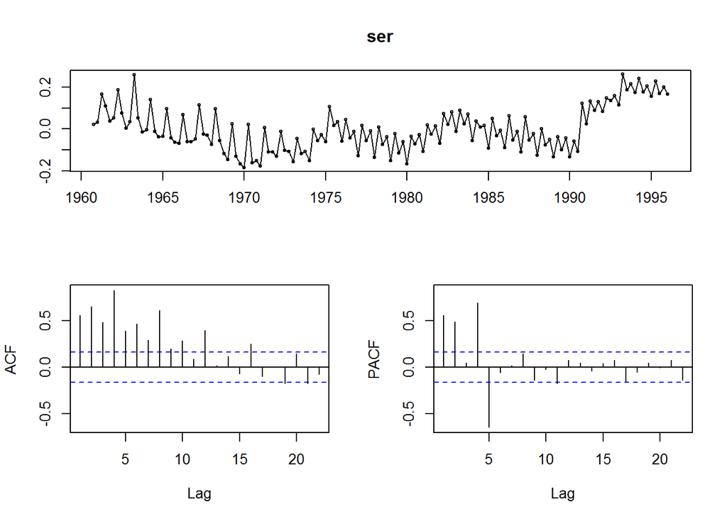

```r
tsdisplay(ser)
```

1.Sezoniškumas matosi dėl trumpų kilimų ir kritimų kievienais metais.

2.Ciklas motosi kelių metų bendras kilimas ir poto kritimas.Pirmas ciklas 1960-1970m., antras ciklas 1970-1980m., trečias ciklas 1980-1990m. ir toliau prasideda ketvirtas ciklas.

3.Trendo nėra.

Tačiau ar duomenys pakankamai horizontalus ir ju variacija pastovi patikrinsime su nsdiffs funkcija

```r
n<-nsdiffs(ser) # siuloma diferencijavimo eile 0
#Todel galime teigti, kad diferencijuoti nebereikia
kpss.test(ser)
```

```
##
##  KPSS Test for Level Stationarity
##
## data:  ser
## KPSS Level = 1.0861, Truncation lag parameter = 2, p-value = 0.01
```

```r
# p-value<0.05 H0 atmetame, duomenys nera stacionaruss ir nesezoniniai.
# Vadinasi reikia panaikinti sezoniskuma
ser1<-diff(ser, lag=2)
kpss.test(ser1)
```

```
##
##  KPSS Test for Level Stationarity
##
## data:  ser1
## KPSS Level = 0.13458, Truncation lag parameter = 2, p-value = 0.1
```

```r
## p-value>0.05 H0 priimame, duomenys yra stacionarus ir nesezoniniai.
```

4. Pagalvokite ar eilutei `ser` reikalinga Box-Cox transformaciją - sprendimą argumentuokite. Jei reikalinga, tai užtikrinkite, kad visi žemiau panaudoti modeliai naudotų tą pačią transformaciją.

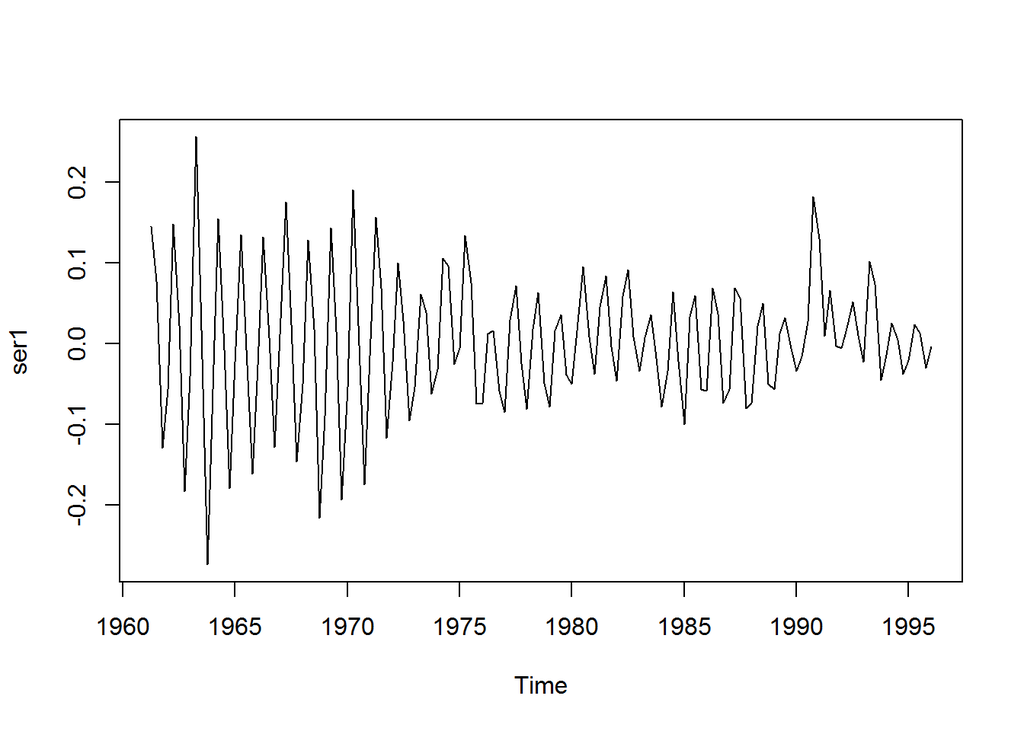

```r
plot(ser1) # svyravimai skirtingais laiko momentasi yra nevienodi,todel box.cox transformacija turetu  buti naudinga.
```

```r
lambda1<-BoxCox.lambda(ser1) ## transformacijos lambda 1.093087
lambda1
```

```
## [1] 1.093087
```

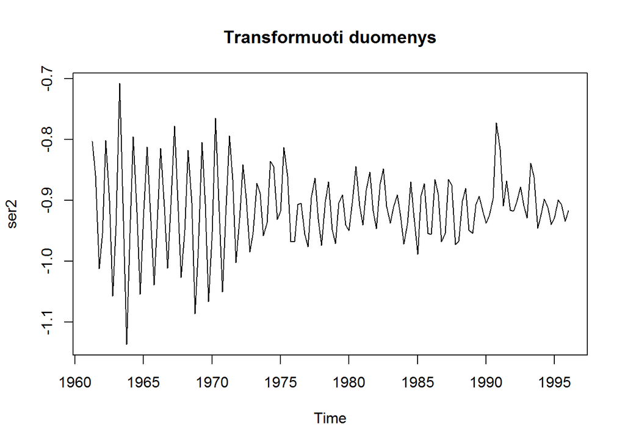

```r
ser2<-BoxCox(ser1,lambda1) ## atliekame transformacija
plot(ser2, main="Transformuoti duomenys")
```

```r
#Is grafiko matome, kad transformacija nieko reiksmingo neatliko.
#vadinasi siems duomenims Box-cox transformacijos nereikalinga
```

2. Modeliavimas.
1. Eilutei `ser` panaudoje `ets` funkcija raskite siūlomą eksponentinio glodinimo modelį. Paaiškinkite ką reiškia modelio žymėjimai. Šį modeli vadinsime `mod1`.

```r
mod1<-ets(ser1)
mod1 #siulomas modelis ETS(A,N,A) reiskia additive errors, none trend, additive season
```

```
## ETS(A,N,A)
##
## Call:
##  ets(y = ser1)
##
##   Smoothing parameters:
##     alpha = 0.0752
##     gamma = 0.4492
##
##   Initial states:
##     l = 0.0016
##     s=-0.0435 -0.1636 0.0454 0.1617
##
##   sigma:  0.0433
##
##       AIC      AICc       BIC
## -175.0099 -174.3784 -157.3601
```

The first letter denotes the error type (“A”, “M” or “Z”); the second letter denotes the trend type (“N”,“A”,“M” or “Z”); and the third letter denotes the season type (“N”,“A”,“M” or “Z”). In all cases, “N”=none, “A”=additive, “M”=multiplicative and “Z”=automatically selected.

Šaltinis: http://www.inside-r.org/packages/cran/forecast/docs/ets

2. Pabandykite paieškoti geresnių alternatyvų. Išbandykite kitus du variantus. Kuris modelis atrodo geriausias? Kodėl? Geriausią pasirinktą modelį vadinsime `mod2`. Aiškiai įvardinkite kurį modelį pasirinkote. Kuo jis skiriasi nuo `mod1`?
3. Eilutei `ser` pritaikykite `auto.arima` funkciją. Pakomentuokite ką reiškia modelio žymėjimai? Šį modelį vadinsime `mod3`. Ar pasiūlyta integruotumo eilė sutampa su 1.c atsakyme jūsų pasiūlyta eile.

```r
mod3<-auto.arima(ser1)
mod3 #siulomas modelis ARIMA(1,0,1)(1,0,2)[4] with zero mean
```

```
## Series: ser1
## ARIMA(1,0,1)(1,0,2)[4] with zero mean
##
## Coefficients:
##           ar1     ma1    sar1     sma1     sma2
##       -0.1691  0.9715  0.9430  -0.4402  -0.2200
## s.e.   0.0809  0.0213  0.0187   0.0859   0.0838
##
## sigma^2 estimated as 0.001071:  log likelihood=280.11
## AIC=-548.22   AICc=-547.59   BIC=-530.57
```

```r
#(p,d,q)(P,D,Q)
#Mazosios raides - nesezonine modelio dalis
#p - autoregresine modelio dalis
#d - diferencijavimo eile
#q - moving average modelio dalis
#Didziosios raides -  sezonine modelio dalis
#P - autoregresine modelio dalis
#D - diferencijavimo eile
#Q - moving average modelio dalis
#Indeksas salia antruju skliaustu reiskia periodu skaiciu per sezona.
#Integravimo eiles sutampa.1.c buvo siuloma 0 ir 2.c siuloma taip pat 0
```

4. Paeksperimentuokite su kitomis galimomis specifikacijomis (pabandykite bent dvi). Kuri atrodo geriausia? Pasirinktą modelį vadinsime `mod4`.

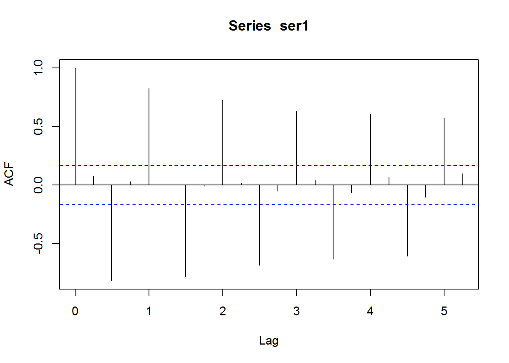

```r
#Remiantis ACF ir PartilaACF grafikais pabandysime sukurti modelius. (Pagal "Hyndman2014a: Forecasting - Principles and Practice" vadovėlio 76psl "ACF and PACF interpretation")
acf(ser1)
```

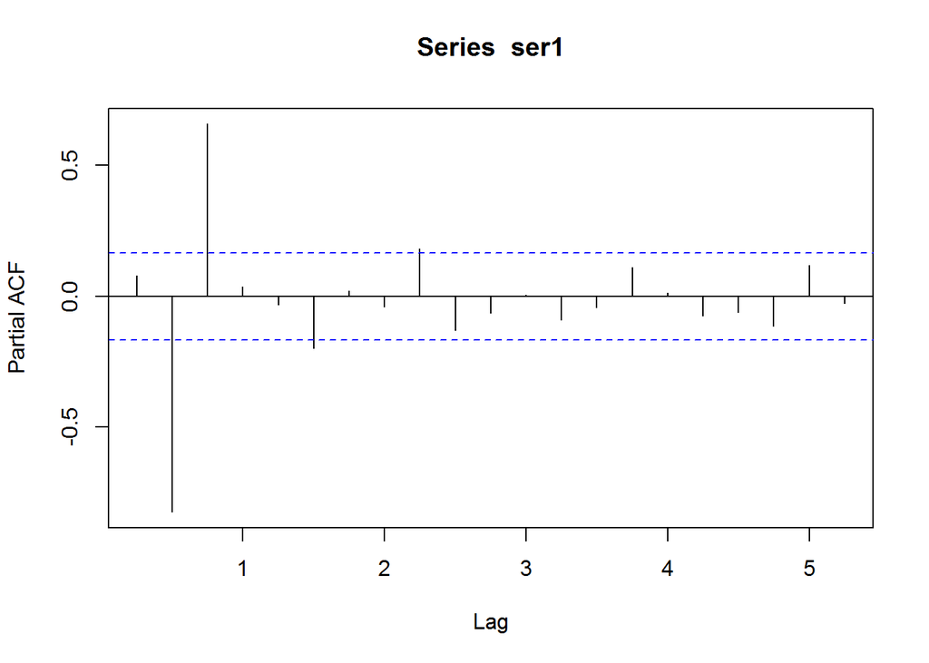

```r
#nors testas kpss.test teige, kad duomenys yra stacionarus ir nesezonianiai ir acf grafiko galime patyti, kad jie yra ryskiai sezoniniai
pacf(ser1)
```

```r
#Kadangi yra padaryta klaida bandant duomenys padaryti stacionariais ir nesezonianiais, kursime kitus modelius panasius i auto.arima +-1 koeficientams (p,d,q)(P,D,Q):
ban1=arima(ser1, order = c(2,0,0),seasonal = list(order=c(2,0,1),period=4))
ban2=arima(ser1, order = c(0,0,1),seasonal = list(order=c(1,0,1),period=4))
accuracy(ban1)
```

```
##                        ME       RMSE        MAE       MPE     MAPE
## Training set 0.0007556948 0.03819494 0.02749237 0.3503462 107.1476
##                   MASE      ACF1
## Training set 0.2911782 0.1125683
```

```r
accuracy(ban2)
```

```
##                         ME       RMSE       MAE       MPE     MAPE
## Training set -4.321876e-05 0.03432982 0.0242317 -2.375529 102.1824
##                   MASE       ACF1
## Training set 0.2566437 -0.1911077
```